# Activity Quality Prediction

Jesus A. Gonzalez

25 de septiembre de 2015

## Introduction

In this project we use machine learning techniques to predict the quality in which people performed some exercises, specifically, five different types of barbell lifts. The data used to perform this task comes from the “Human Activity Recognition” (HAR) project (more precisely the Weight Lifting Exercise Dataset (WLE) from the HAR project) that can be found at http://groupware.les.inf.puc-rio.br/har [1]. The WLE dataset contains data about six young and healty participants that performed a set of ten repetitions of the “Unilateral Dumbbell Biceps Curl” exercise in five different ways/classes describing how the exercise was performed:

- A, Exactly according to the specification
- B, Throwing the elbows to the front
- C, Lifting the dumbbell only halfway
- D, Lowering the dumbbell only halfway
- E, Throwing the hips to the front

The class distribution is as shown in figure 1.

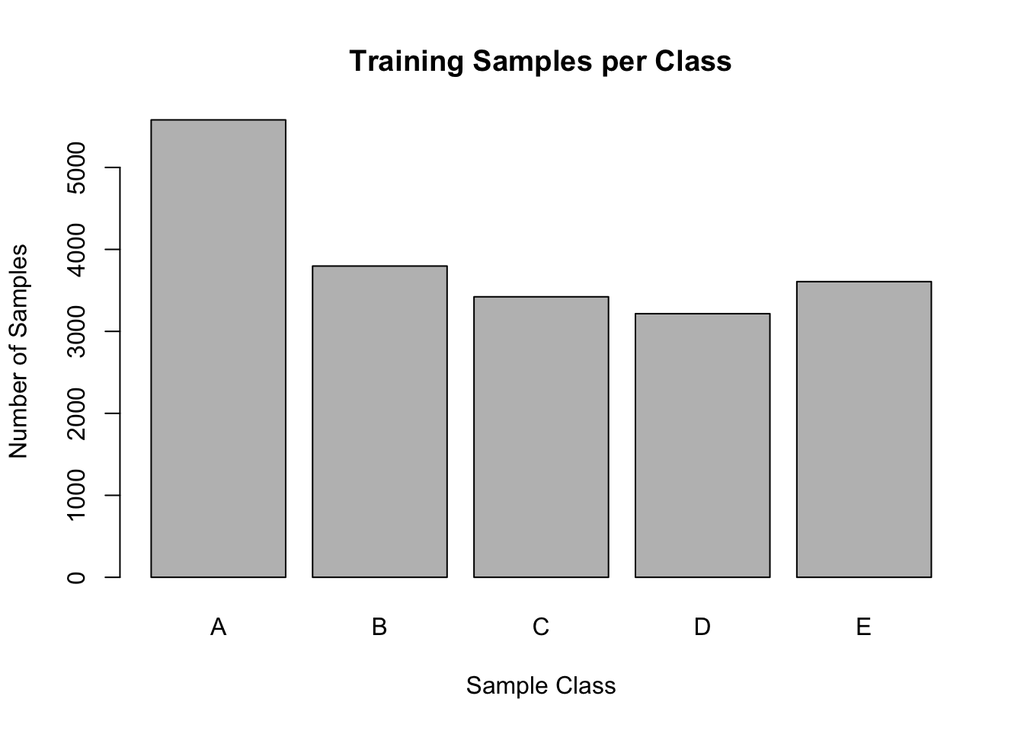

Figure 1. Class Distribution in the Training Set of the WLE Dataset.

The WLE dataset consists of 19,622 training examples and 20 testing examples with a set of 160 descriptive features each. The features of this dataset correspond to measures obtained from accelerometers located at the belt, forearm, arm, and dumbell of the six participants.

## Preprocessing

We loaded the training and testing sets and removed those attributes with no values (“NAs”) because those did not contribute information to our dataset. These values were not imputed because there were not enough data to predict other values. We tried to use more preprocessing with principal component analysis but that did not improve accuracy and we did not used it. No more preprocessing was used. After preprocessing, we ended with 52 features for both, the training and testing sets. The names of the features are shown below.

```
##  [1] "roll_belt"            "pitch_belt"           "yaw_belt"
##  [4] "total_accel_belt"     "gyros_belt_x"         "gyros_belt_y"
##  [7] "gyros_belt_z"         "accel_belt_x"         "accel_belt_y"
## [10] "accel_belt_z"         "magnet_belt_x"        "magnet_belt_y"
## [13] "magnet_belt_z"        "roll_arm"             "pitch_arm"
## [16] "yaw_arm"              "total_accel_arm"      "gyros_arm_x"
## [19] "gyros_arm_y"          "gyros_arm_z"          "accel_arm_x"
## [22] "accel_arm_y"          "accel_arm_z"          "magnet_arm_x"
## [25] "magnet_arm_y"         "magnet_arm_z"         "roll_dumbbell"
## [28] "pitch_dumbbell"       "yaw_dumbbell"         "total_accel_dumbbell"
## [31] "gyros_dumbbell_x"     "gyros_dumbbell_y"     "gyros_dumbbell_z"
## [34] "accel_dumbbell_x"     "accel_dumbbell_y"     "accel_dumbbell_z"
## [37] "magnet_dumbbell_x"    "magnet_dumbbell_y"    "magnet_dumbbell_z"
## [40] "roll_forearm"         "pitch_forearm"        "yaw_forearm"
## [43] "total_accel_forearm"  "gyros_forearm_x"      "gyros_forearm_y"
## [46] "gyros_forearm_z"      "accel_forearm_x"      "accel_forearm_y"
## [49] "accel_forearm_z"      "magnet_forearm_x"     "magnet_forearm_y"
## [52] "magnet_forearm_z"     "classe"
```

Figure 2. Features of the WLE Datase After Removing NAs

## Building the Classification Model

```r
library(caret)
set.seed(1548)
training <- read.csv("pml-training-2.csv")
testing <- read.csv("pml-testing-2.csv")
fit1 <- train(classe ~ ., data=training, method="svmLinear", trControl=trainControl(method="cv"))
print(fit1$results)
```

```
##   C  Accuracy     Kappa  AccuracySD    KappaSD
## 1 1 0.7868208 0.7289554 0.008259704 0.01062857
```

```r
predict(fit1, testing)
```

```
##  [1] C A B C A E D B A A C A B A E E A B B B
## Levels: A B C D E
```

Figure 3. Code Used for the Classification Task with the WLE Dataset.

## References

Ugulino, W.; Cardador, D.; Vega, K.; Velloso, E.; Milidiu, R.; Fuks, H. Wereable Computing: Accelerometers’ Data Classification of Body Postures and Movements. Proceedigs of 21st Brazilian Symposium on Artificial Intelligence. Advances in Artificial Intelligence - SBIA 2012. In: Lecture Notes in Computer Science., pp. 52 - 61. Curitiba, PR: Springer Berlin / Heidelberg, 2012. ISBN 978-3-642-34458-9. DOI: 10.1007/978-3-642-34459-6_6.